# Машинное обучение с использованием пакета mlr3

© Андрей Огурцов

[figure not shown]

## ML-фреймворки на R

1. **mlr3: `mlr3`+`mlr3pipelines`+`mlr3learners`+`mlr3tuning`+`mlr3measures`+…**

Очень похож на `scikit-learn`

В основе лежат R6-классы, в качестве бекенда по умолчанию для табличных данных используется `data.table`

Все процессы построения моделей объединены в граф вычислений

2. **tidymodels: `rsample`+`recipes`+`parsnip`+`tune`+`yardstick`+…**

Построен вокруг функций, а не объектов с методами, как mlr3 (но есть конвергентное сходство с mlr3)

3. **(2.5) H2O**

Не совсем фреймворк и не совсем на R

## Экосистема mlr3

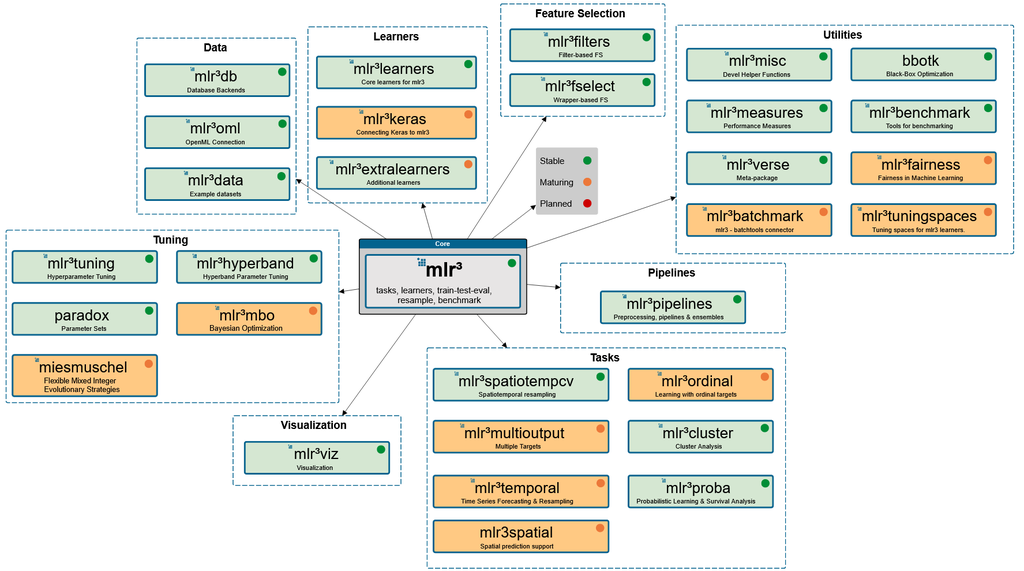

*Source: https://mlr3book.mlr-org.com/introduction.html*

## Экосистема mlr3 (продолжение)

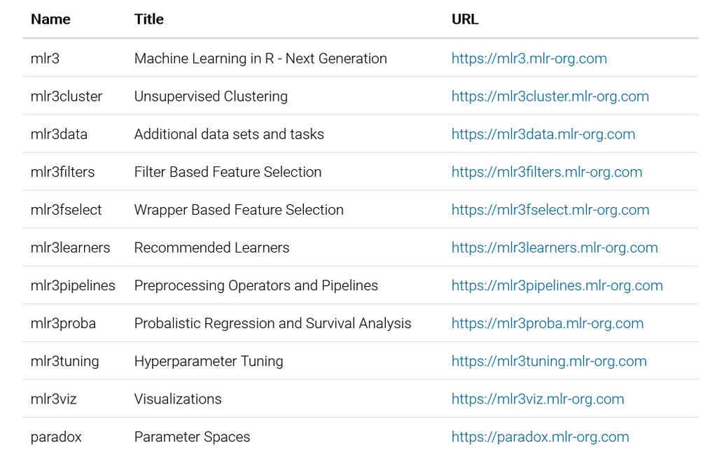

*Source: https://mlr3verse.mlr-org.com/*

## Экосистема mlr3 (продолжение)

```r
library(mlr3verse)
```

Дополнительные пакеты:

- Analysis of benchmark experiments: `mlr3benchmark`
- Task interface for data bases: `mlr3db`
- Connector to OpenML: `mlr3oml`
- Additional learners: `mlr3extralearners`
- Hyperband tuning algorithm: `mlr3hyperband`
- Spatio-temporal resampling: `mlr3spatiotempcv`
- etc.

## Основные составляющие ML-пайплайна

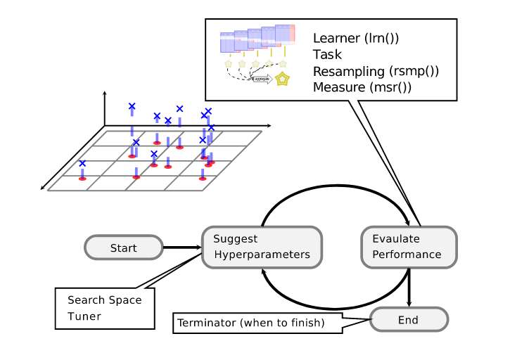

*Source: https://mlr3book.mlr-org.com/optimization.html*

## Основные составляющие ML-пайплайна (продолжение)

```r
# Задача
data("Sonar", package = "mlbench")
task <- TaskClassif$new(id = "Sonar", backend = Sonar,
                        target = "Class")
task <- as_task_classif(Sonar, target = "Class",
                        positive = "M")
task
```

```
## <TaskClassif:Sonar> (208 x 61)
## * Target: Class
## * Properties: twoclass
## * Features (60):
##   - dbl (60): V1, V10, V11, V12, V13, V14, V15, V16, V17, V18, V19, V2,
##     V20, V21, V22, V23, V24, V25, V26, V27, V28, V29, V3, V30, V31,
##     V32, V33, V34, V35, V36, V37, V38, V39, V4, V40, V41, V42, V43,
##     V44, V45, V46, V47, V48, V49, V5, V50, V51, V52, V53, V54, V55,
##     V56, V57, V58, V59, V6, V60, V7, V8, V9
```

## Основные составляющие ML-пайплайна (продолжение)

```r
# Модель
learner_rpart <- LearnerClassif$new("classif.rpart")
learner_rpart <- mlr_learners$get("classif.rpart")
learner_rpart <- lrn("classif.rpart",
                     predict_type = "prob",
                     minsplit = 50)
learner_rpart$param_set$values$minsplit <- 33 #insert_named()
learner_rpart
```

```
## <LearnerClassifRpart:classif.rpart>
## * Model: -
## * Parameters: xval=0, minsplit=33
## * Packages: mlr3, rpart
## * Predict Type: prob
## * Feature types: logical, integer, numeric, factor, ordered
## * Properties: importance, missings, multiclass, selected_features,
##   twoclass, weights
```

## Основные составляющие ML-пайплайна (продолжение)

```r
# Обучение
learner_rpart$train(task, row_ids = 1:120)
learner_rpart$model
```

```
## n= 120
##
## node), split, n, loss, yval, (yprob)
##       * denotes terminal node
##
## 1) root 120 23 R (0.19166667 0.80833333)
##   2) V31< 0.4322 51 22 R (0.43137255 0.56862745)
##     4) V12>=0.1694 31 10 M (0.67741935 0.32258065) *
##     5) V12< 0.1694 20  1 R (0.05000000 0.95000000) *
##   3) V31>=0.4322 69  1 R (0.01449275 0.98550725) *
```

## Основные составляющие ML-пайплайна (продолжение)

```r
# Предсказание на новых данных
preds <- learner_rpart$predict_newdata(newdata = Sonar)
preds
```

```
## <PredictionClassif> for 208 observations:
##     row_ids truth response     prob.M    prob.R
##           1     R        R 0.05000000 0.9500000
##           2     R        M 0.67741935 0.3225806
##           3     R        R 0.01449275 0.9855072
## ---
##         206     M        R 0.01449275 0.9855072
##         207     M        R 0.01449275 0.9855072
##         208     M        R 0.01449275 0.9855072
```

## Основные составляющие ML-пайплайна (продолжение)

```r
# Кросс-валидация
cv3 <- rsmp("cv", folds = 3)
resample_results <- resample(task, learner_rpart, cv3)
```

[output not shown]

```r
resample_results
```

```
## <ResampleResult> of 3 iterations
## * Task: Sonar
## * Learner: classif.rpart
## * Warnings: 0 in 0 iterations
## * Errors: 0 in 0 iterations
```

## Пайпы и графы

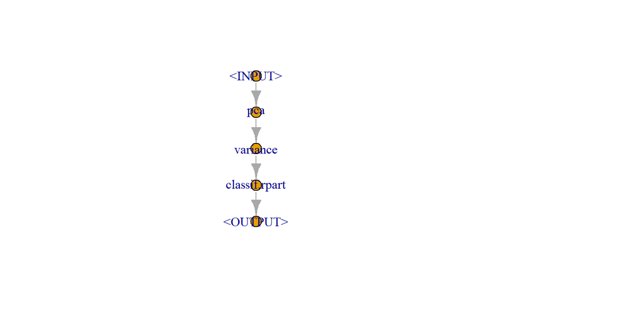

```r
pca <- po("pca")
filter <- po("filter",
             filter = mlr3filters::flt("variance"),
             filter.frac = 0.5)
learner_po <- po("learner",
                 learner = lrn("classif.rpart"))
graph <- pca %>>% filter %>>% learner_po
graph$plot()
```

## Пайпы и графы (продолжение)

```r
library(data.table)
library(mlr3verse)

dt <- data.table(
  x = factor(c(1:3, 3), levels = 1:3), y = 1
)
dt_test <- data.table(
  x = factor(c(1:3, 3, 4), levels = 1:4), y = 1
)
task <- TaskRegr$new("y", backend = dt,
                     target = "y")
task_test <- TaskRegr$new("y_test", backend = dt_test,
                          target = "y")
```

## Пайпы и графы (продолжение)

```r
g <- po("fixfactors") %>>%
  po("imputeoor", affect_columns = selector_all())
g$train(task)
```

```
## $imputeoor.output
## <TaskRegr:y> (4 x 2)
## * Target: y
## * Properties: -
## * Features (1):
##   - fct (1): x
```

```r
g$predict(task_test)$imputeoor.output$data()
```

```
##    y        x
## 1: 1        1
## 2: 1        2
## 3: 1        3
## 4: 1        3
## 5: 1 .MISSING
```

## Пайпы и графы (продолжение)

```r
g <- po("imputeoor") %>>%
  po("fixfactors")
g$train(task)
```

```
## $fixfactors.output
## <TaskRegr:y> (4 x 2)
## * Target: y
## * Properties: -
## * Features (1):
##   - fct (1): x
```

```r
g$predict(task_test)$fixfactors.output$data()
```

```
##    y    x
## 1: 1    1
## 2: 1    2
## 3: 1    3
## 4: 1    3
## 5: 1 <NA>
```

## Пайпы и графы (продолжение)

```r
g <- po("fixfactors") %>>%
  po("imputemode")
g$train(task)
```

```
## $imputemode.output
## <TaskRegr:y> (4 x 2)
## * Target: y
## * Properties: -
## * Features (1):
##   - fct (1): x
```

```r
g$predict(task_test)$imputemode.output$data()
```

```
##    y x
## 1: 1 1
## 2: 1 2
## 3: 1 3
## 4: 1 3
## 5: 1 3
```

## Полезные ссылки

- Учебник от разработчиков https://mlr3book.mlr-org.com/index.html
- Шпаргалка https://cheatsheets.mlr-org.com/mlr3.pdf
- Галерея примеров https://mlr3gallery.mlr-org.com/
- Слегка устаревший хабрапост https://habr.com/ru/company/ods/blog/491566/
- Коннектор к `torch` с реализацией сети tabnet https://github.com/mlr-org/mlr3torch
- Интерпретация моделей mlr3 https://cran.r-project.org/web/packages/flashlight/vignettes/mlr3.html

## Вопросы

[figure not shown]

## Спасибо за внимание!

Презентация создана при помощи **revealjs**

https://github.com/statist-bhfz/ml_mlr3